# 3 Data Visualization

## 3.3 Aesthetic Mappings

Podemos ainda mapear por meio de cores e formas para separar em grupos dentro do gráfico, fazemos isso fornecendo esses argumentos dentro de aes.

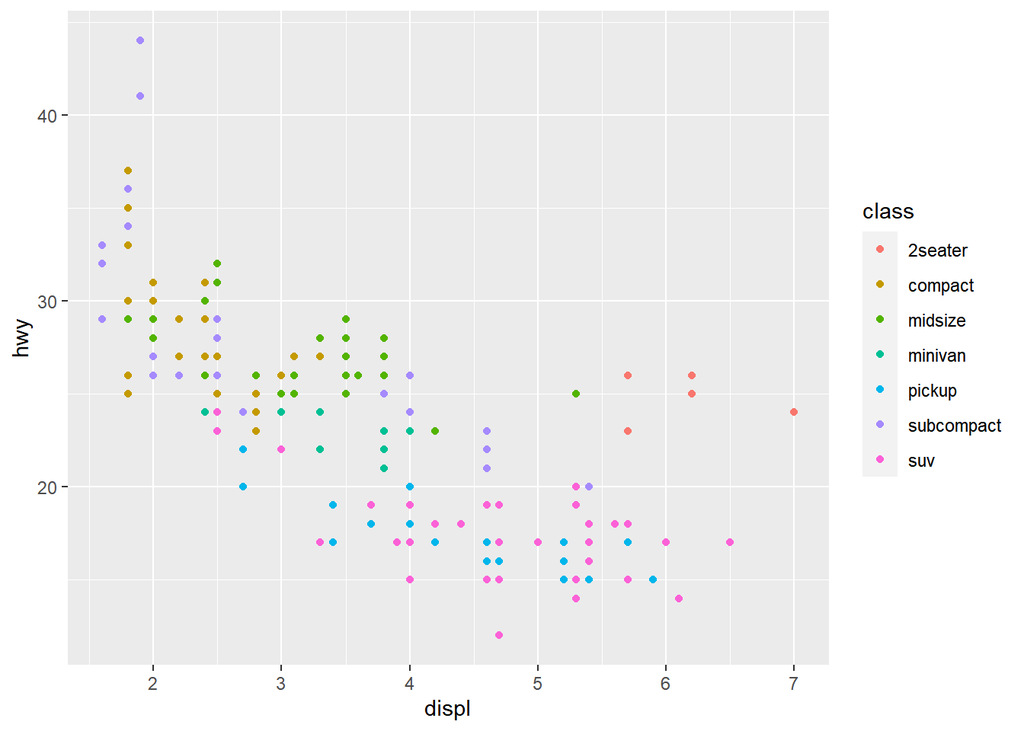

```r
ggplot(mpg) + geom_point(mapping= aes(displ,hwy,color=class))
```

Podemos perceber que os carros que pareciam não se ater ao padrão linear são carros compactos, para 2 pessoas, provavelmente esportivos, são menores e mais leves que a maioria dos carros presentes nessa area do gráfico.

Fizemos o mapeamento da classe do carro de acordo com a cor, poderiamos ter usado outros argumentos para isso,como size (altera o tamanho dos pontos), shape (forma dos pontos) , alpha (tranparencia)…

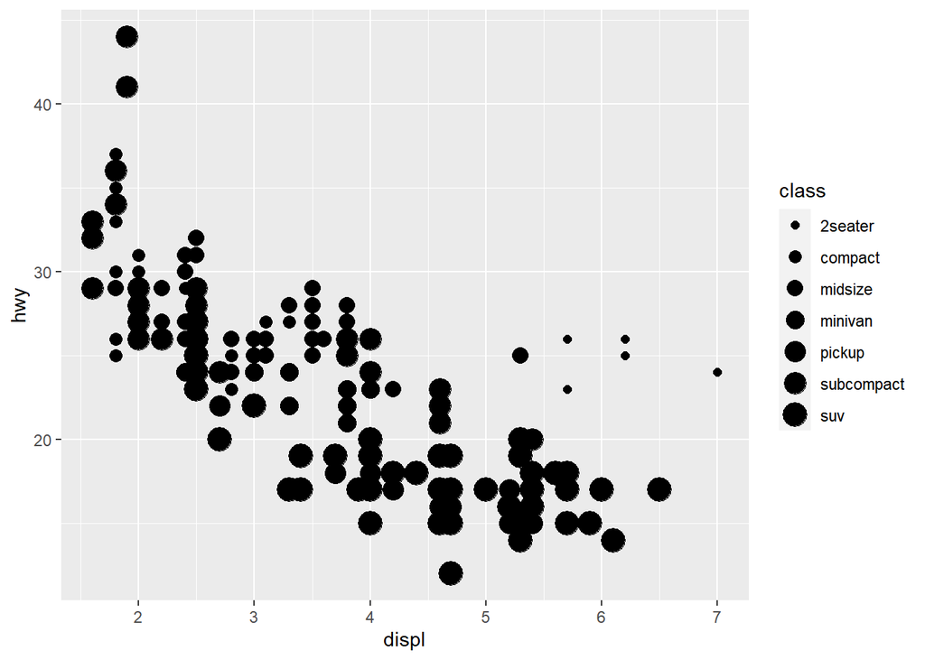

```r
ggplot(mpg) + geom_point(mapping= aes(displ,hwy,size=class))
```

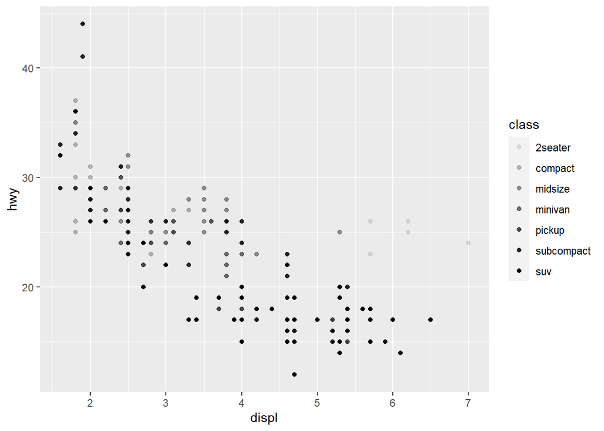

```r
ggplot(mpg) + geom_point(mapping= aes(displ,hwy,alpha=class))
```

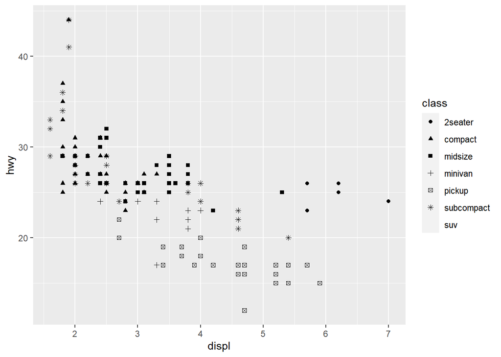

```r
ggplot(mpg) + geom_point(mapping= aes(displ,hwy,shape=class))
```

As SUVs sumiram quando classificamos por shape, o ggplot só usa 6 formas por vez como padrão e o resto acaba sem ser plottado. Se quisermos alterar isso devemos fazer manualmente e fora do aes. EX:

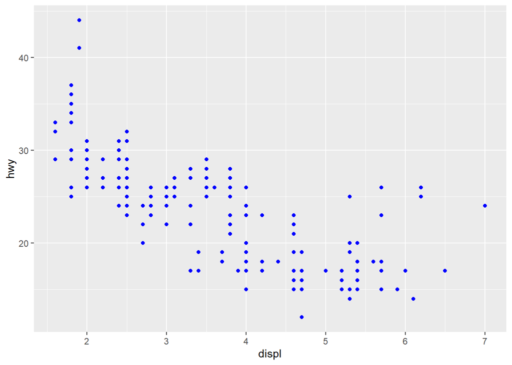

```r
ggplot(mpg) + geom_point(mapping=aes(displ,hwy),color = 'blue')
```

Consertando o exemplo shape.

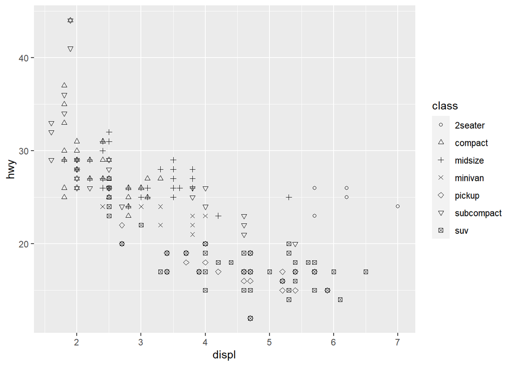

```r
mpg$class <- mpg$class %>% as.factor
ggplot(mpg) + geom_point(mapping= aes(x= displ,y = hwy,shape=class))+
  scale_shape_manual(values = 1:nlevels(mpg$class))
```

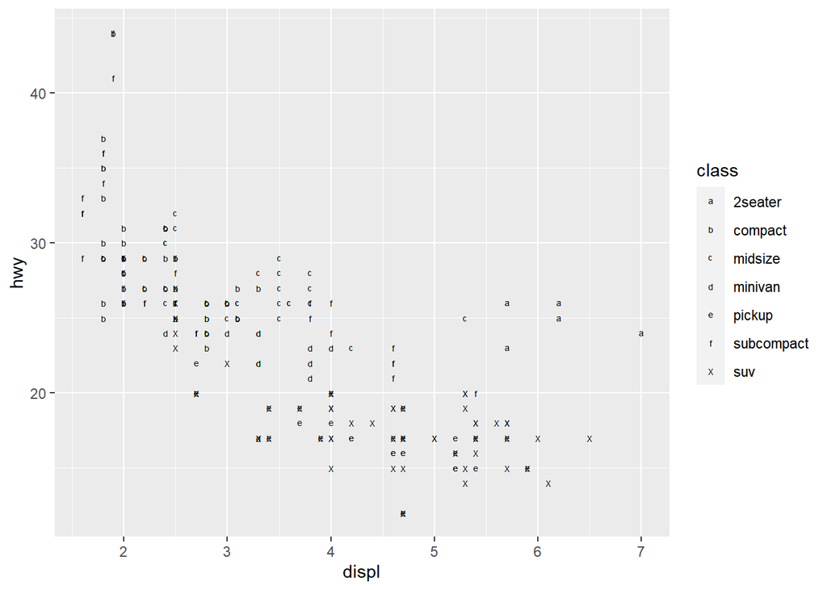

```r
ggplot(mpg) + geom_point(mapping= aes(x= displ,y = hwy,shape=class))+ scale_shape_manual(values = c('a','b','c','d','e','f','X'))
```

## Exercicios 3.3.1

```r
?mpg
```

```
## starting httpd help server ... done
```

As categoricas são: Manufacturer, Model, Trans, Drv, Fl e Class. O resto contínua.

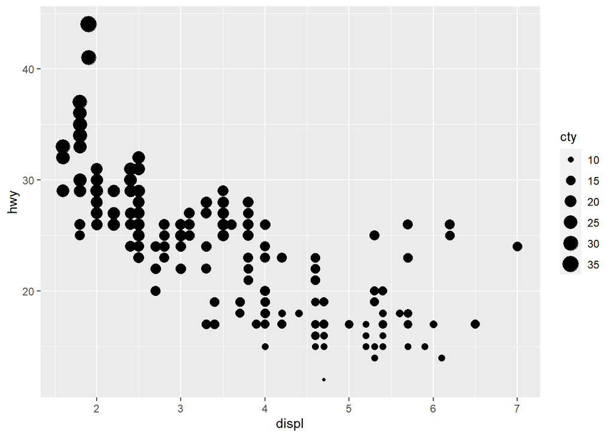

```r
ggplot(mpg) + geom_point(aes(displ,hwy,size=cty))
```

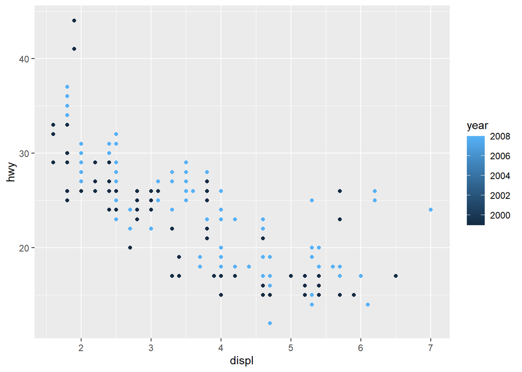

```r
ggplot(mpg) + geom_point(aes(displ,hwy,color=year))
```

Quando pedimos para uma variável continua ser classificada por cor ou size as varíaveis são agrupadas entre intervalos e apresentada no gráfico. Já a classificação por shape retorna erro.

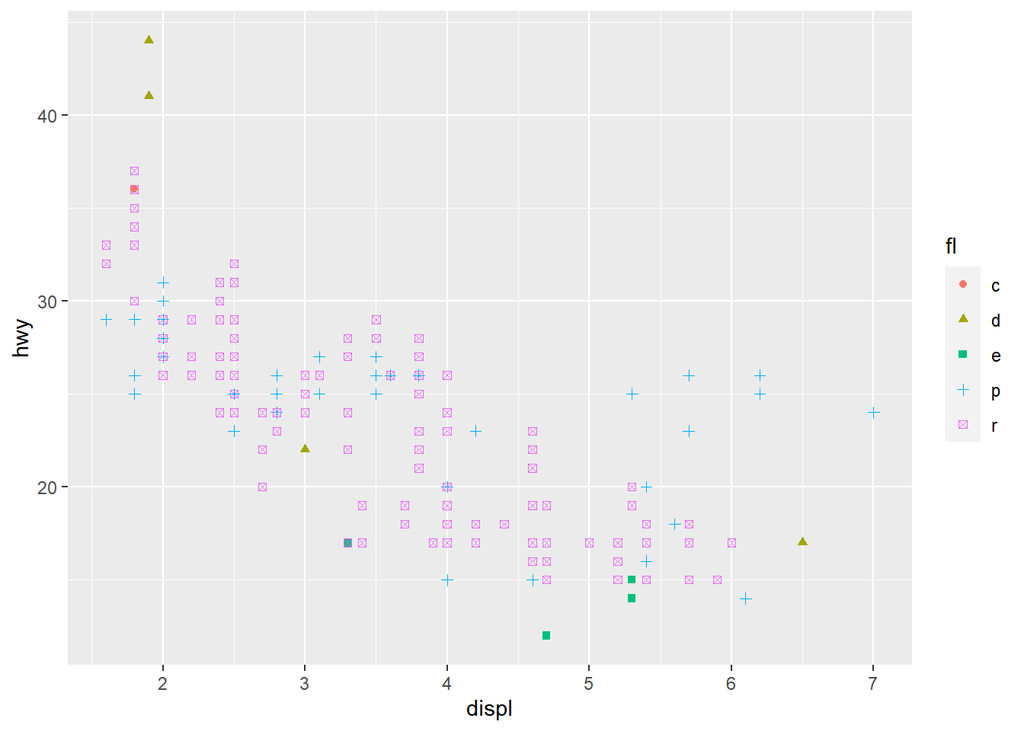

```r
ggplot(mpg) + geom_point(aes(displ,hwy,color= fl,shape=fl))
```

Quando mapeamos uma variável para mais de um visual, temos a combinação desses apresentada.

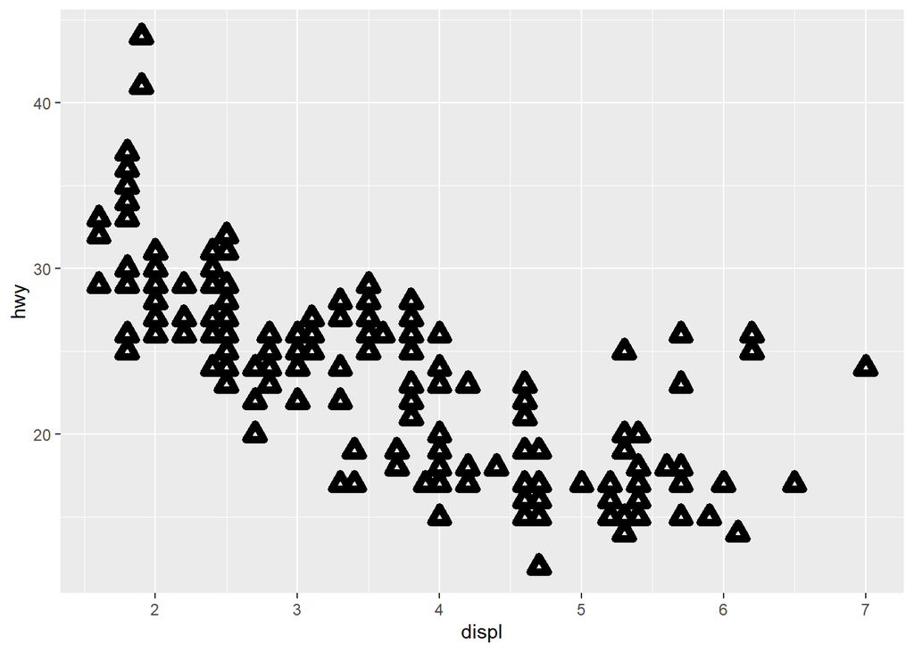

```r
ggplot(mpg) + geom_point(aes(displ,hwy),stroke=3,shape=2,colour='black',fill='white')
```

Stroke define o tamanho da borda do ponto caso ele não seja preenchido podemos perceber.

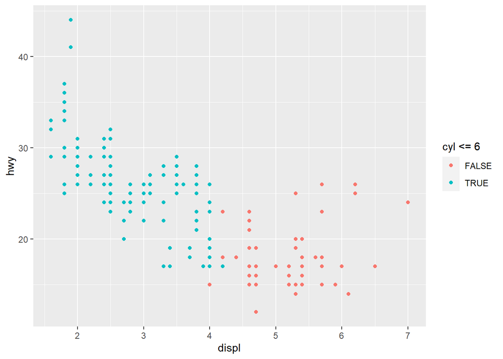

```r
ggplot(mpg) + geom_point(aes(displ,hwy,color=cyl<=6))
```

Podemos fazer a classificação por meio de uma condição que vai dividir em true ou false.

## 3.5 Facets

Vários Gráficos serão plottados ao mesmo tempo. Uso da função facet_wrap(), primeiro argumento é uma formula com um nome de variável.

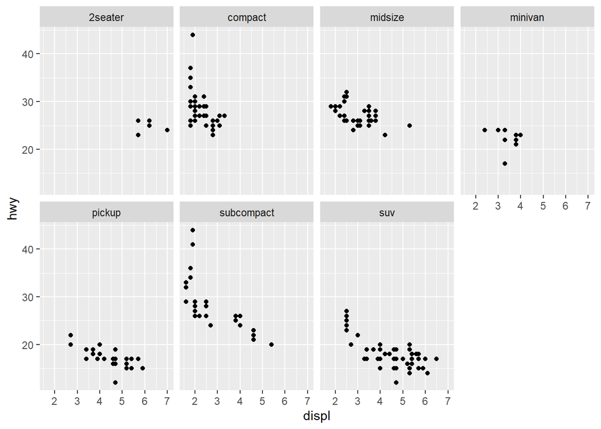

```r
ggplot(mpg) +
  geom_point(aes(displ,hwy)) +
  facet_wrap(~class,nrow=2)
```

Todos os eixos ficam iguais por padrão, podemos alterar caso desejado.

Podemos dividir em duas variáveis, essa divisão , da seguinte maneira. Usamos o comando grid.

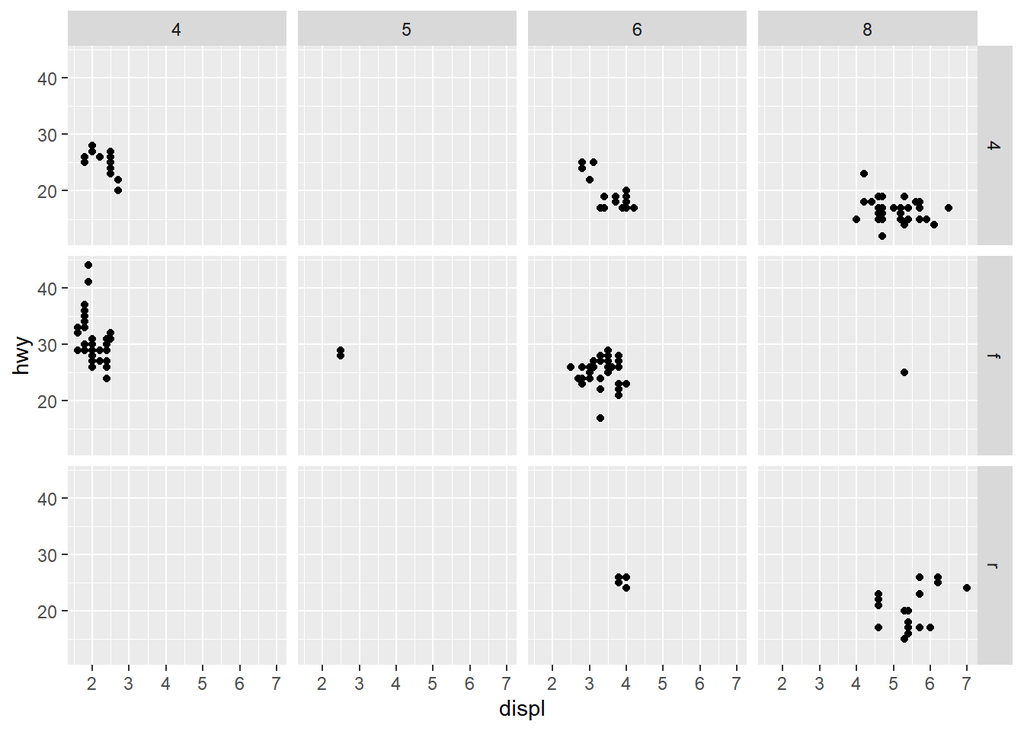

```r
ggplot(mpg) +
  geom_point(aes(displ,hwy)) +
  facet_grid(drv~cyl)
```

## Exercícios 3.5.1

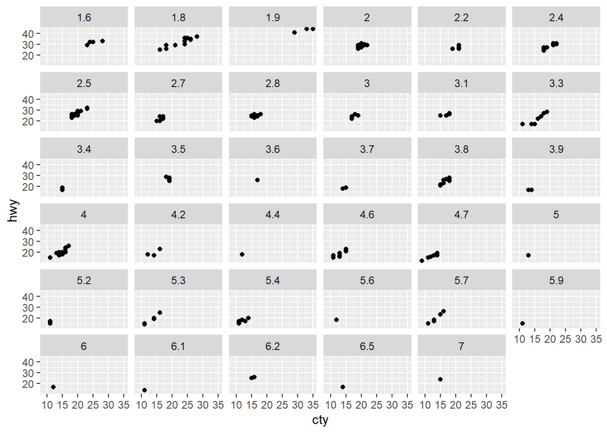

```r
ggplot(mpg) +
  geom_point(aes(cty,hwy)) +
  facet_wrap(~displ)
```

Faz para todos os valores

Os plots vazios quando aplicamos grid com duas variáveis categóricas signifacam que não tinham observações com aquelas duas caracteristicas simultaneamente.

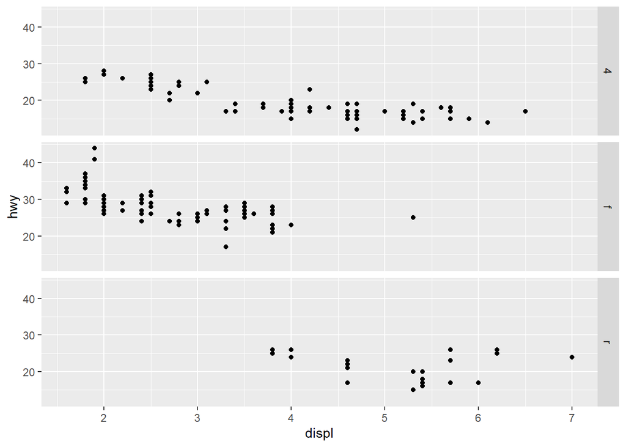

```r
ggplot(data = mpg) +
  geom_point(mapping = aes(x = displ, y = hwy)) +
  facet_grid(drv ~ .)
```

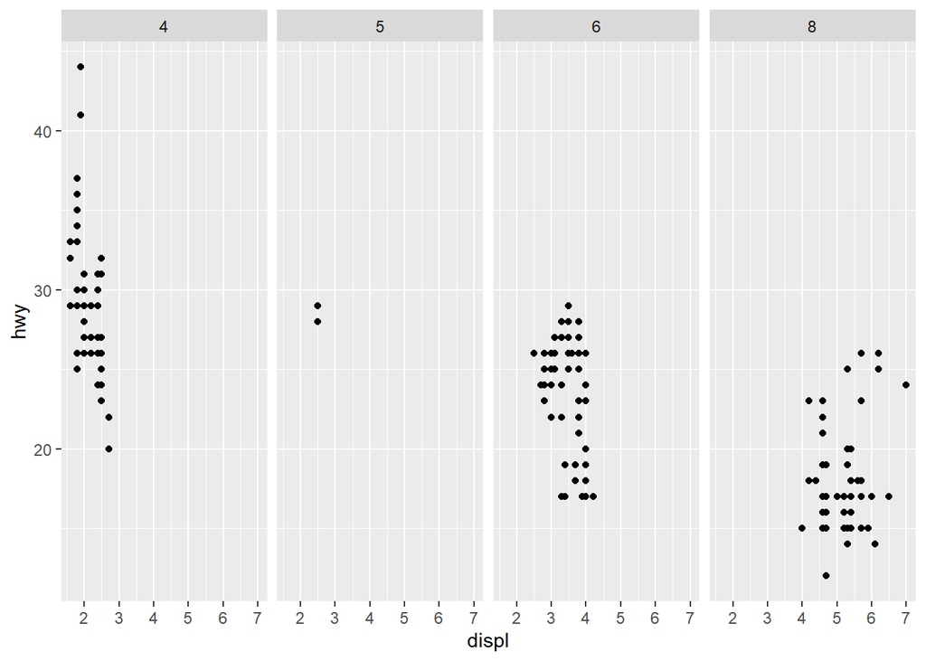

```r
ggplot(data = mpg) +
  geom_point(mapping = aes(x = displ, y = hwy)) +
  facet_grid(. ~ cyl)
```

O . serve para determinar se os gráficos estarão dispostos na vertical ou horizontal

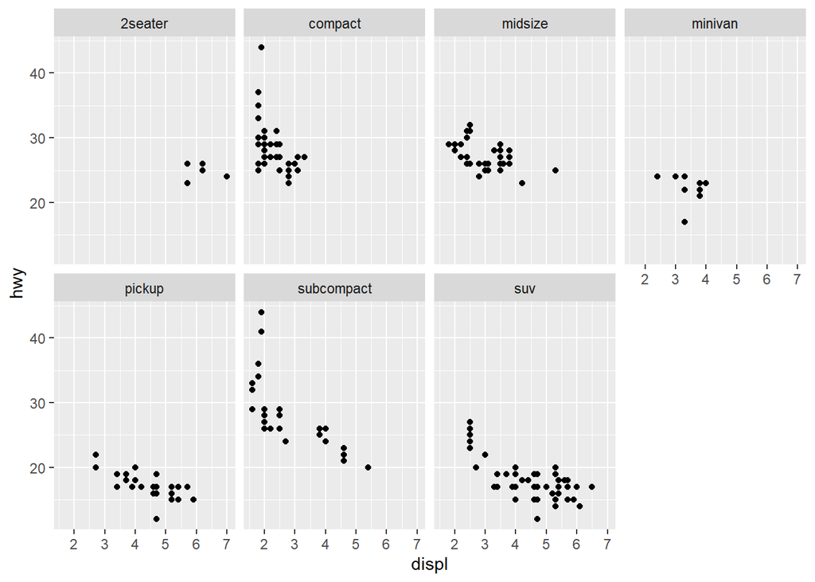

```r
ggplot(data = mpg) +
  geom_point(mapping = aes(x = displ, y = hwy)) +
  facet_wrap(~ class, nrow = 2)
```

Separadamente conseguimos analisar um padrão dentro da classe com mais facilidade, quando tudo está no mesmo gráfico é mais fácil analisar um padrão geral dos dados. Comparar 2 a 2 pode ser mais fácil quando estão separados.

nrow e ncol determinam o numero de colunas e linhas desejados, deve usar apenas 1 deles dado que o outro é definido por consequência, usados para definir a disposição dos gráficos na tela.

Tem uma vantagem, apenas visual, para não deixar os gráficos muito alongados.

## 3.6 Geometric Objects

O geom antes de cada gráfico define o objeto geometrico usado para descrever os dados (Point, Bar,Line). Por exemplo podemos descrever os mesmos dados de maneiras diferentes.

```r
ggplot(data = mpg) +
  geom_point(mapping = aes(x = displ, y = hwy))
```

[output not shown]

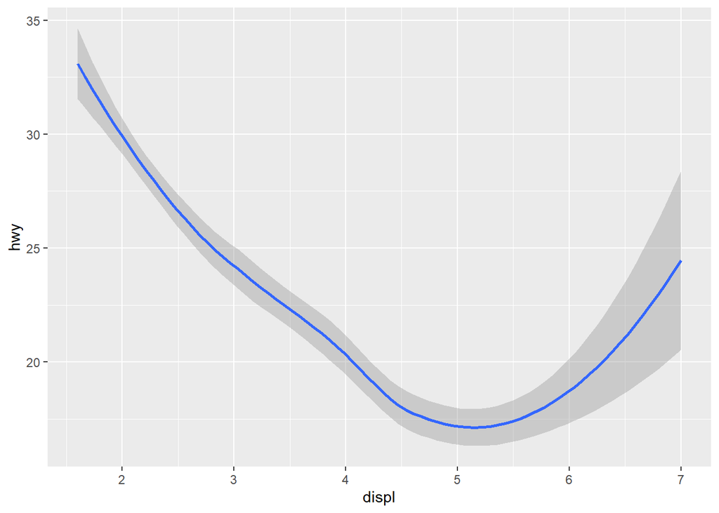

```r
ggplot(data = mpg) +
  geom_smooth(mapping = aes(x = displ, y = hwy))
```

Os mesmos dados apresentados de maneira diferentes, um por meio de uma regressão e outro por meio por meio dos pontos.

Todas funções geom recebem um argumento em mapping, mas de maneiras diferentes, não podemos definir a forma de uma linha mas podemos definir a forma de pontos, então shape não faz sentido para geom_line ou geom_smooth. Mas o tipo de linha pode ser alterado em line e smooth com linetype.

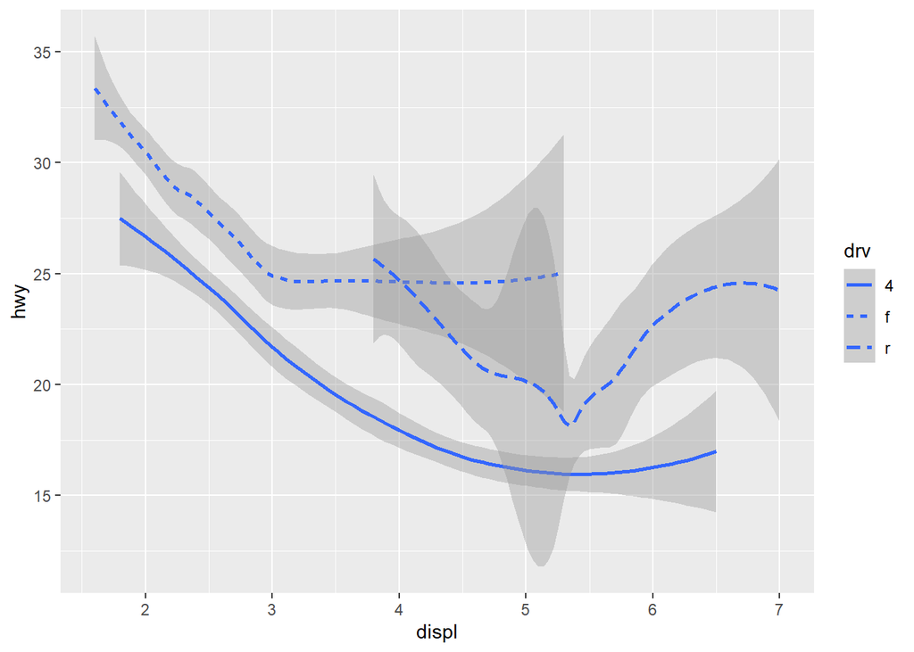

```r
ggplot(data = mpg) +
  geom_smooth(mapping = aes(x = displ, y = hwy, linetype = drv))
```

Podemos fazer geoms diferentes em um gráfico, se sobrepondo caso seja do interesse:

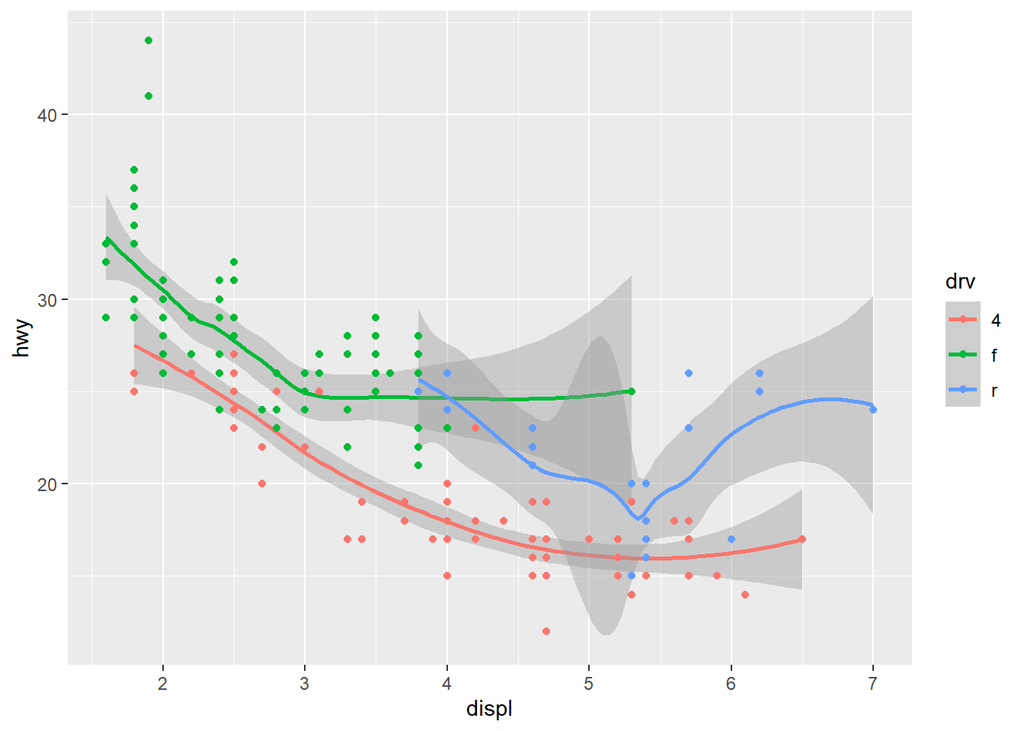

```r
ggplot(mpg,mapping = aes(x = displ, y = hwy,color=drv)) +
  geom_smooth() +
  geom_point()
```

Existem maneiras diferentes de escrever os códigos, como fornecer o mapping individualmente ou na chamada, mas isso não altera o resultado.

Podemos usar group para fazer agrupamentos, mas a legenda não é apresentada e os grupos não são identificados. Dessa maneira, é mais conveniente usar color ou linetype, para fazer essas separações, dado que o agrupamento é feito pelas mesmas além de identifica-las.

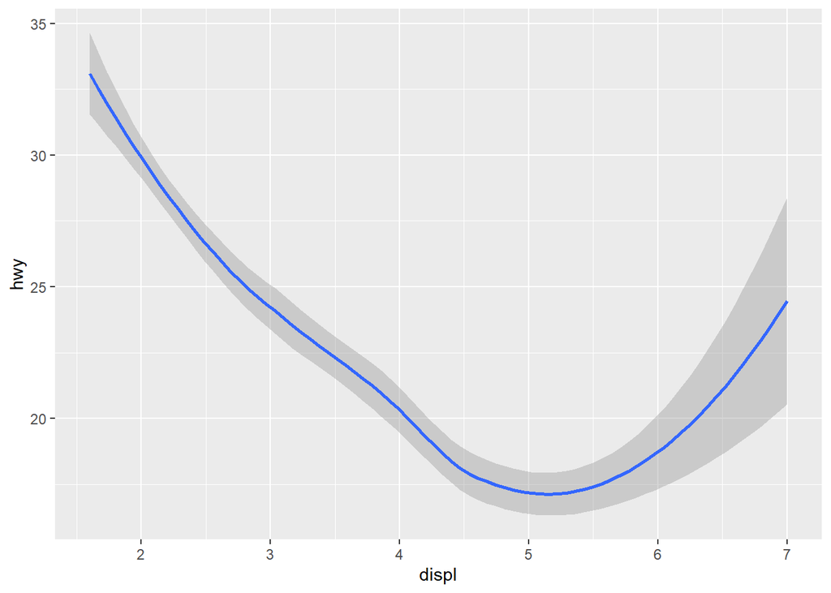

```r
ggplot(data = mpg) +
  geom_smooth(mapping = aes(x = displ, y = hwy))
```

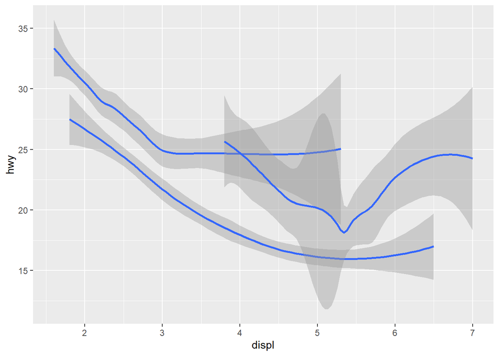

```r
ggplot(data = mpg) +
  geom_smooth(mapping = aes(x = displ, y = hwy, group = drv))
```

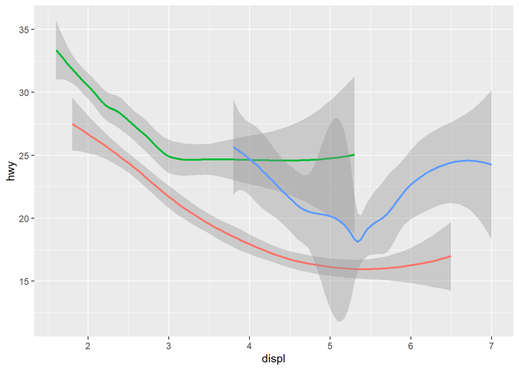

```r
ggplot(data = mpg) +
  geom_smooth(
    mapping = aes(x = displ, y = hwy, color = drv),
    show.legend = FALSE
  )
```

Quando mapeamos em ggplot é um mapeamento global e serve para todos geoms, podemos mapear globalmente e localmente para agrupa de maneiras diferentes. O exemplo a seguir mostra isso.

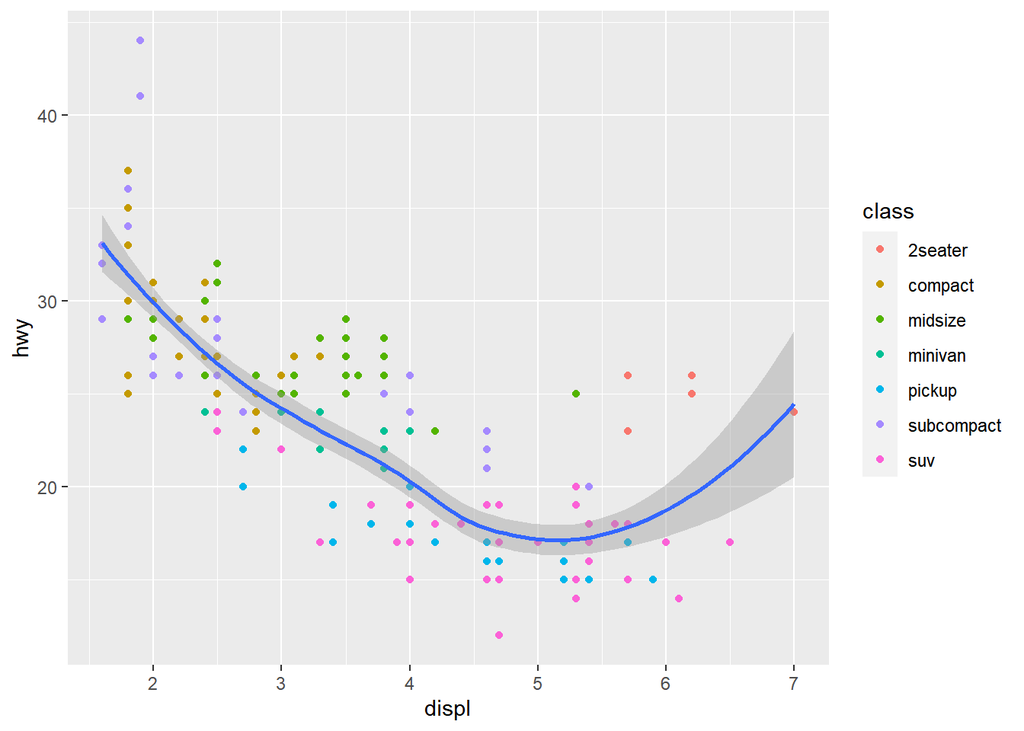

```r
ggplot(data = mpg, mapping = aes(x = displ, y = hwy)) +
  geom_point(mapping = aes(color = class)) +
  geom_smooth()
```

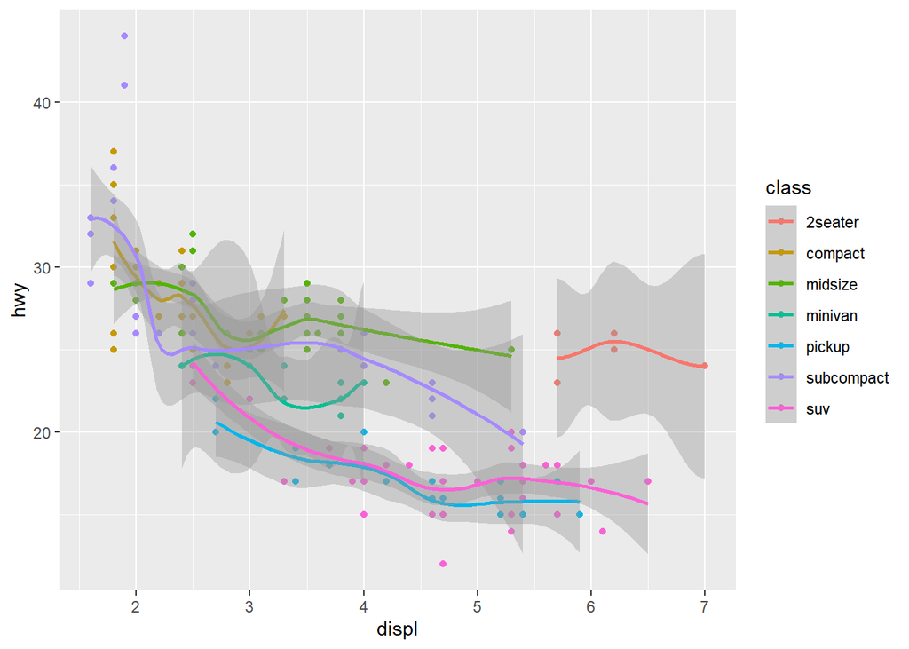

```r
ggplot(data = mpg, mapping = aes(x = displ, y = hwy,color = class)) +
  geom_point() +
  geom_smooth()
```

Fazer localmente a separação de cores fica melhor para a analíse dado que as cores nos pontos já dariam uma noção dos grupos, enquanto quando fazemos globalmente o gráfico fica muito cheio.

Podemos tambem Filtrar o que vai aparecer de acordo com uma variável, tanto localmente quanto globalmetne.

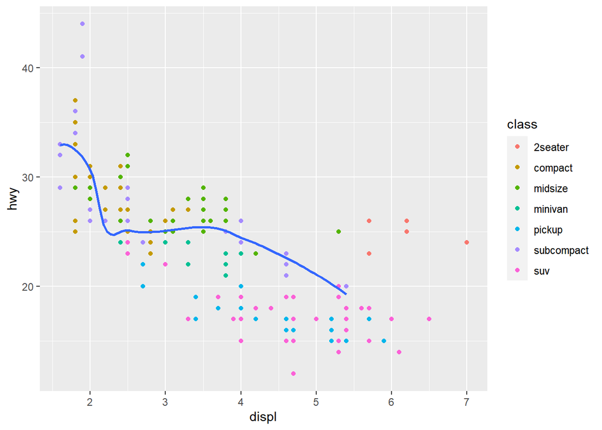

```r
ggplot(data = mpg, mapping = aes(x = displ, y = hwy)) +
  geom_point(mapping = aes(color = class)) +
  geom_smooth(data = filter(mpg, class == "subcompact"),se=F)
```